# Linear Regression

## TL;DR

In simple linear regression, we model one predictor and one outcome—for example, gestational age predicting birthweight. The slope quantifies the expected change in birthweight per additional week of gestation. We assess model fit with R², inspect diagnostic plots for linearity and homoskedasticity, and check residuals for normality. If assumptions are violated, we may add polynomial terms, apply log transformations, or use robust standard errors.

Multivariable linear regression extends this framework to include multiple predictors, allowing us to adjust for potential confounders—variables that influence both the predictor and outcome. Interactions can be added to test whether the effect of one variable depends on another.

Finally, we compare different modeling goals:

- Causal models adjust for known confounders based on domain knowledge (e.g., how maternal smoking or welfare status affect birthweight).
- Predictive models prioritize accuracy and generalizability, sometimes using automated selection methods like stepwise regression or penalized approaches.

Throughout, regression should be guided by both statistical evidence and substantive reasoning; not just significance tests or automatic algorithms.

```r
library(tidyverse)
library(dslabs)
library(ggfortify)  # quick lm diagnostics
library(corrplot)   # correlation heatmaps
library(Hmisc)      # rcorr()
```

## Simple linear regression

Linear regression allows us to quantify the relationship between two variables — not just whether they move together, but by how much (the magnitude). Linear regression can be used to estimate or predict the value of a continuous outcome measurement given a set of risk factors, adjust for confounders when examining the relationship between an exposure and a continuous outcome, and test for effect measure modification.

Linear regression looks at the change in one variable (outcome or response or dependent variable) that corresponds to a given change in the other variable (explanatory variable or exposure or predictor or covariate or independent variable).

Here, we’ll predict birthweight (`bwt`) from gestational age (`gestation`) using an ordinary least squares (OLS) linear regression model.

```r
data <- read.table("KingCounty2001_data.txt", header = TRUE)
head(data)
```

```
##   gender plural age     race parity married  bwt smokeN drinkN firstep welfare
## 1      F      1  31 hispanic      4       1 3118      0      0       1       0
## 2      M      1  23    white      0       1 3466      0      0       1       0
## 3      F      1  24    black      1       0 3147      0      0       1       0
## 4      M      1  26 hispanic      2       1 3969      0      0       1       0
## 5      M      1  34    white      0       0 3005      0      0       1       0
## 6      M      1  15    black      0       0 2920      0      0       1       0
##   smoker drinker wpre wgain education gestation
## 1      N       N  122    22         5        40
## 2      N       N  160    50        12        39
## 3      N       N  150    38        13        40
## 4      N       N  175    15        12        39
## 5      N       N  123    17        17        40
## 6      N       N  180    12         9        36
```

We use the `lm` function to fit the linear regression model, and the `summary` function to output important features of the model, like coefficients and confidence intervals. The primary inputs are formula and data; simple linear regression formula: `outcome ~ predictor`.

```r
m1 <- lm(bwt ~ gestation, data = data)
summary(m1)
```

```
##
## Call:
## lm(formula = bwt ~ gestation, data = data)
##
## Residuals:
##      Min       1Q   Median       3Q      Max
## -2068.46  -301.93    -9.56   273.44  1745.54
##
## Coefficients:
##             Estimate Std. Error t value Pr(>|t|)
## (Intercept)  -1410.7      155.8  -9.055   <2e-16 ***
## gestation      124.1        4.0  31.026   <2e-16 ***
## ---
## Signif. codes:  0 '***' 0.001 '**' 0.01 '*' 0.05 '.' 0.1 ' ' 1
##
## Residual standard error: 475.3 on 2498 degrees of freedom
## Multiple R-squared:  0.2782, Adjusted R-squared:  0.2779
## F-statistic: 962.6 on 1 and 2498 DF,  p-value: < 2.2e-16
```

- Fitted regression line equation: Mean birthweight = 124.1(gestation) – 1410.7
- Slope interpretation: for every 1 week increase in gestational age, birthweight increases by 124.1 grams on average.
- Intercept interpretation: the estimated mean birthweight when gestational age is 0 weeks is -1410.7 grams.

The p-value of the slope coefficient is used to test if the relationship between the outcome and exposure is significant. If the p-value is < 0.05, the slope is not equal to 0 and there is a statistically significant relationship between the outcome and exposure.

One important use of a linear regression model is prediction of a continuous outcome. * Example: the predicted birthweight of a baby with gestational age equal to 40 weeks is 124.1(40) – 1410.7 = 3,553.3 grams. * Example: the predicted birthweight of a baby with gestational age equal to 28 weeks is 124.1(28) – 1410.7 = 2,064.1 grams.

To evaluate model fit, we can use R^2. R^2 is the coefficient of determination, which quantifies the proportion of the variance in the dependent variable that is explained by the independent variable. R^2 ranges from 0 to 1, with higher values indicating a better fit model. In simple linear regression, R^2 is the Pearson correlation coefficient squared.

Let’s compute confidence intervals for these estimates using the `confint` function.

```r
confint(m1)
```

```
##                  2.5 %     97.5 %
## (Intercept) -1716.1938 -1105.1835
## gestation     116.2624   131.9502
```

We can visualize the fitted regression line along with its 95% confidence interval using `geom_smooth(method = "lm", se = TRUE)`. The `method = "lm"` part tells ggplot to add the linear regression line, and `se = TRUE` tells ggplot to add confidence bands (confidence intervals) around the line. Note that the confidence bands are wider where there is less data - this is because there is less information about the relationship between gestational age and birthweight for those range of values (e.g., gestational age less than 30 weeks), which results in more uncertainty and wider confidence bands.

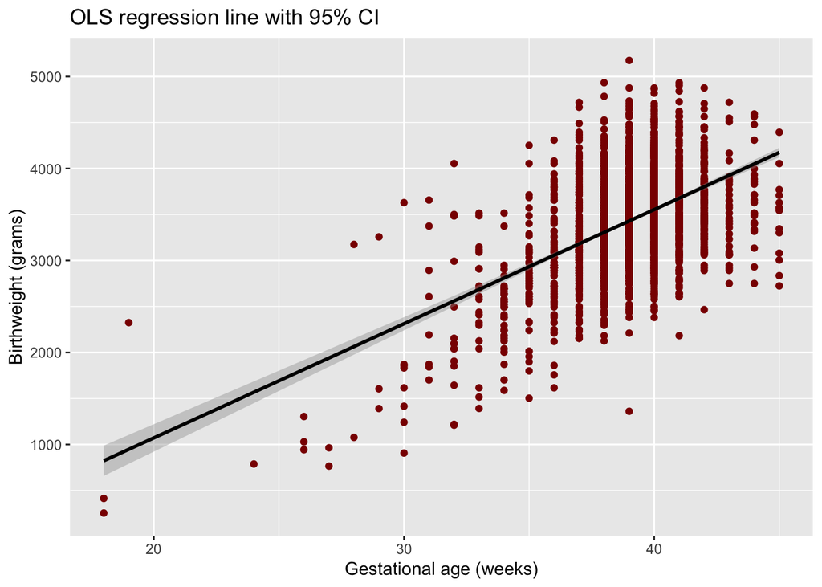

```r
data %>%
  ggplot(aes(gestation, bwt)) +
  geom_point(color = "darkred") +
  geom_smooth(method = "lm", se = TRUE, color = "black") +
  labs(x = "Gestational age (weeks)", y = "Birthweight (grams)",
       title = "OLS regression line with 95% CI")
```

### Checking assumptions

Linear regression assumes:

1. The relationship between the two variables is linear.
2. Residuals have constant variance (homoskedasticity).
3. Residuals are independent and normally distributed.
4. We have independent observations.

We can check if assumptions 1-3 hold graphically. The function `autoplot` from the `ggfortify` package can be used to create plots to check if the assumptions of linear regression are met. Let’s examine diagnostic plots and see if these assumptions are met. Four plots are created; we will use 3 of those plots.

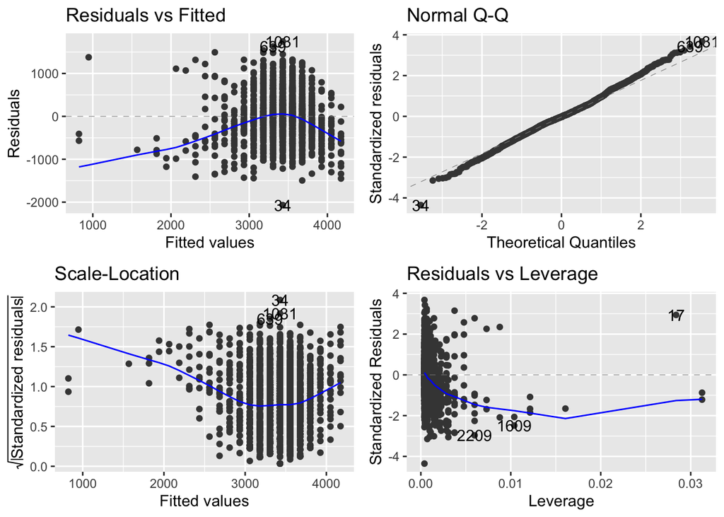

```r
autoplot(m1)
```

A plot of the residuals (difference between the actual values and the values predicted with the regression line) versus the fitted values is used to check linearity. A horizontal line, without distinct patterns is an indication for a linear relationship. We do not have that here, due to the relatively small amount of data with lower values of gestational age, so this assumption is not met. A potential solution would be to transform the exposure variable (log, square root, etc.).

A plot of the square root of the standardized residuals versus the fitted values is used to check the homoscedasticity assumption. This is called a scale-location or spread-location plot. A horizontal line with equally spread points is a good indication of homoscedasticity. The homoscedasticity assumption is violated in our dataset due to the relatively small amount of data with lower values of gestational age. A potential solution would be to transform the outcome variable (log, square root, etc.).

A quantile-quantile plot (Normal Q-Q plot) is used to check the normality assumption. The normality assumption is met if the standardized residuals follow the straight dashed line. Sometimes it’s difficult to tell for sure if this assumption is met so we can use the Shapiro-Wilk test to test the normality assumption.

```r
shapiro.test(residuals(m1))     # normality test
```

```
##
##  Shapiro-Wilk normality test
##
## data:  residuals(m1)
## W = 0.99666, p-value = 2.551e-05
```

The normality assumption is not met in the dataset since the p-value is < 0.05. A few potential solutions include applying data transformations to the exposure variable, using robust regression methods that are less sensitive to non-normal data or outliers, and removing outliers.

As a final note on checking assumptions, the only way to check the independence assumption is having knowledge of the study / sampling design. You can ascertain this information by contacting those responsible for data collection, read study documentation, or create a subset of the original dataset that only includes independent pairs of observations. The independence assumption holds for this dataset.

## Multivariate linear regression

Multivariate linear regression can be used to explore more complex relationships involving a continuous outcome and two or more explanatory variables. The assumptions for multivariate linear regression are the same as simple linear regression, but we won’t be checking the assumptions for the following models.

Now we’ll extend the model to include multiple predictors. Multivariable regression allows us to adjust for confounders — other factors that may influence the outcome.

Our new question:

- After adjusting for gestational age and other maternal factors, is participation in the First Steps prenatal care program associated with higher birthweight?

We can first make a boxplot to see if the distributions of birthweight are different for those who participated in the First Steps program and those did not.

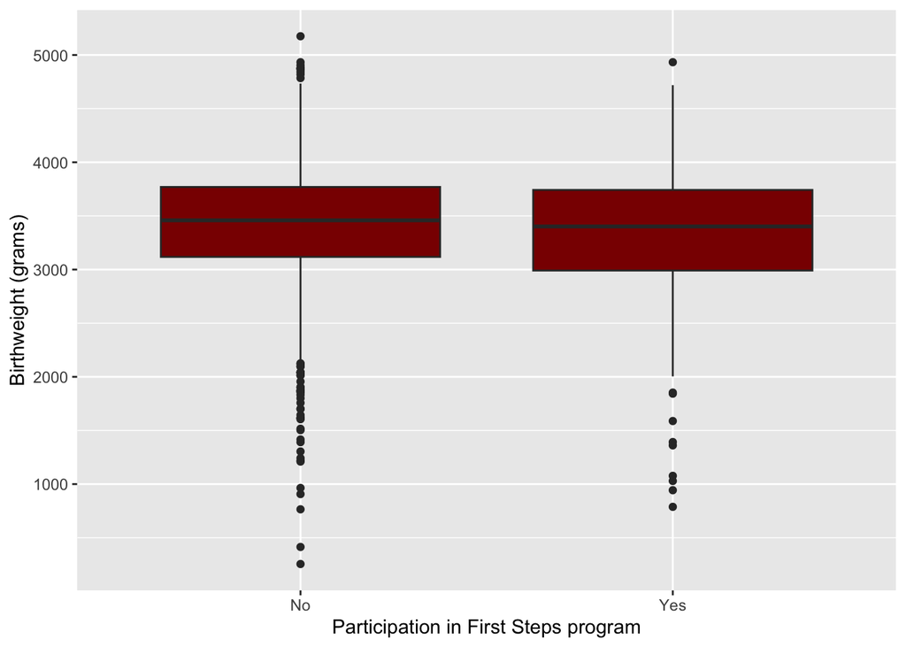

```r
# Create a new column for firstep for better looking plots
data1 <- data %>%
  mutate(firstep_cat = as.factor(ifelse(firstep == 0, "No", "Yes")),
         firstep = as.factor(firstep))

# Look at the distribution of birthweight for each program category
data1 %>% ggplot(aes(as.factor(firstep_cat), bwt)) +
  geom_boxplot(fill = "darkred") +
  ylab("Birthweight (grams)") +
  xlab("Participation in First Steps program")
```

### Crude model

A linear regression model with one explanatory variable (exposure) of interest is called a **crude** model, and we’ll start with the crude model. No other covariates have been “adjusted” for, meaning no other covariates have been added to the model yet.

```r
m <- lm(bwt ~ firstep, data = data)
summary(m)
```

```
##
## Call:
## lm(formula = bwt ~ firstep, data = data)
##
## Residuals:
##     Min      1Q  Median      3Q     Max
## -3169.7  -306.9    34.3   345.3  1750.3
##
## Coefficients:
##             Estimate Std. Error t value Pr(>|t|)
## (Intercept)  3424.69      12.21 280.581   <2e-16 ***
## firstep       -66.18      30.40  -2.177   0.0296 *
## ---
## Signif. codes:  0 '***' 0.001 '**' 0.01 '*' 0.05 '.' 0.1 ' ' 1
##
## Residual standard error: 558.9 on 2498 degrees of freedom
## Multiple R-squared:  0.001894,   Adjusted R-squared:  0.001494
## F-statistic: 4.739 on 1 and 2498 DF,  p-value: 0.02958
```

From this model, mean bwt = -66.18(`firstep` = 1) + 3424.69. `firstep` is called an indicator variable.

Interpretation:

- Infants of participants in the First Steps program weighed, on average, 66.18 grams less at birth.
- Mean bwt for program participants: 3358.51
- Mean bwt for non-participants: 3424.69

### Adjusted model

When other covariates are added to the crude model, the model becomes an **adjusted model**. To add more covariates to a linear regression model, just use the `+` sign. The interpretations of coefficients in the model output change slightly.

```r
m1 <- lm(bwt ~ firstep + gestation, data = data)
summary(m1)
```

```
##
## Call:
## lm(formula = bwt ~ firstep + gestation, data = data)
##
## Residuals:
##      Min       1Q   Median       3Q      Max
## -2033.17  -300.12   -13.39   276.11  1738.79
##
## Coefficients:
##              Estimate Std. Error t value Pr(>|t|)
## (Intercept) -1396.289    155.998  -8.951   <2e-16 ***
## firstep       -42.037     25.856  -1.626    0.104
## gestation     123.910      4.001  30.973   <2e-16 ***
## ---
## Signif. codes:  0 '***' 0.001 '**' 0.01 '*' 0.05 '.' 0.1 ' ' 1
##
## Residual standard error: 475.2 on 2497 degrees of freedom
## Multiple R-squared:  0.2789, Adjusted R-squared:  0.2783
## F-statistic: 482.9 on 2 and 2497 DF,  p-value: < 2.2e-16
```

Interpretation:

- Infants of participants in the First Steps program weighed, on average, 42.037 grams less at birth, adjusting for gestational age.
- For every 1 week increase in gestation, birthweight increases by 123.91 grams on average, holding all other covariates constant.

### Effect Measure Modification

Now suppose we wanted to test if the relationship between birthweight and gestational age is different for infants whose mothers participated in the First Steps program and those whose mothers did not participate. This is testing effect measure modification, and we can create an interaction term to test for the presence of effect measure modification.

In R, the syntax `covariate1 * covariate2` fits a model with terms `covariate1`, `covariate2`, and `covariate1 * covariate2` in it.

```r
m2 <- lm(bwt ~ firstep*gestation, data = data)
summary(m2)
```

```
##
## Call:
## lm(formula = bwt ~ firstep * gestation, data = data)
##
## Residuals:
##      Min       1Q   Median       3Q      Max
## -2032.04  -300.60   -11.24   277.69  1738.69
##
## Coefficients:
##                    Estimate Std. Error t value Pr(>|t|)
## (Intercept)       -1440.077    176.788  -8.146 5.89e-16 ***
## firstep             154.516    374.075   0.413    0.680
## gestation           125.036      4.536  27.565  < 2e-16 ***
## firstep:gestation    -5.072      9.629  -0.527    0.598
## ---
## Signif. codes:  0 '***' 0.001 '**' 0.01 '*' 0.05 '.' 0.1 ' ' 1
##
## Residual standard error: 475.2 on 2496 degrees of freedom
## Multiple R-squared:  0.279,  Adjusted R-squared:  0.2781
## F-statistic:   322 on 3 and 2496 DF,  p-value: < 2.2e-16
```

The p-value for the interaction term is not <0.05, so it should not be kept in the model. This means there is no evidence of effect measure modification.

## Collinearity

Collinearity occurs when independent variables (covariates) are highly correlated with one another. This makes it difficult for the model to estimate individual effects on the outcome variable, and inflates the variance of the regression coefficients leading to unstable estimates and wider CIs. Often, a decision about which to include in the final model is needed.

We can calculate and visualize the correlation between each pair of numeric covariates. Let’s first make `gender`, `smoker`, `drinker`, and `race` numeric. Here, I have chosen “white” to be the reference race group. Then we can make the other integer variables into numeric variables by using the `across` and `where` functions inside `mutate`.

```r
data_cor <- data %>%
  mutate(gender = ifelse(gender == "F", 0, 1),
         smoker = ifelse(smoker == "N", 0, 1),
         drinker = ifelse(drinker == "N", 0, 1),
         race = case_when(
           race == "white" ~ 0,
           race == "hispanic" ~ 1,
           race == "black" ~ 2,
           race == "other" ~ 3,
           TRUE ~ 4
         ))

data_cor <- data_cor %>%
  mutate(across(where(is.integer), as.numeric))
```

Collinearity is usually checked with a correlation matrix, and you can specify if you would like to use Pearson or Spearman correlation, depending on the distributions of the variables. We can again use the `cor` function to calculate each correlation and save it as an object to use for plotting the correlation values.

```r
# Only keep numerical variables
vars <- c("age", "parity", "bwt", "wpre", "wgain", "education", "gestation")
data_subset <- data_cor[, vars]
corr_matrix <- cor(data_subset, method = "spearman")
```

We can plot the correlation values using the `corrplot` function from the `corrplot` package. The more negative the correlation, the more red the circle. The more positive the correlation, the more blue the circle. Larger absolute values of correlation result in larger circles and darker hues.

The default is a square plot that is symmetric along the diagonal with no correlation values displayed, and the names of the variables in red. Using `type = "upper"` we can remove the bottom triangle of circles since they are redundant. We can set `tl.col = "black"` to make the variable names black, and `tl.srt = 45` to put them at a 45 degree angle, making them easier to read. Adding `method = "number"` will replace the circles with the actual numerical correlation values.

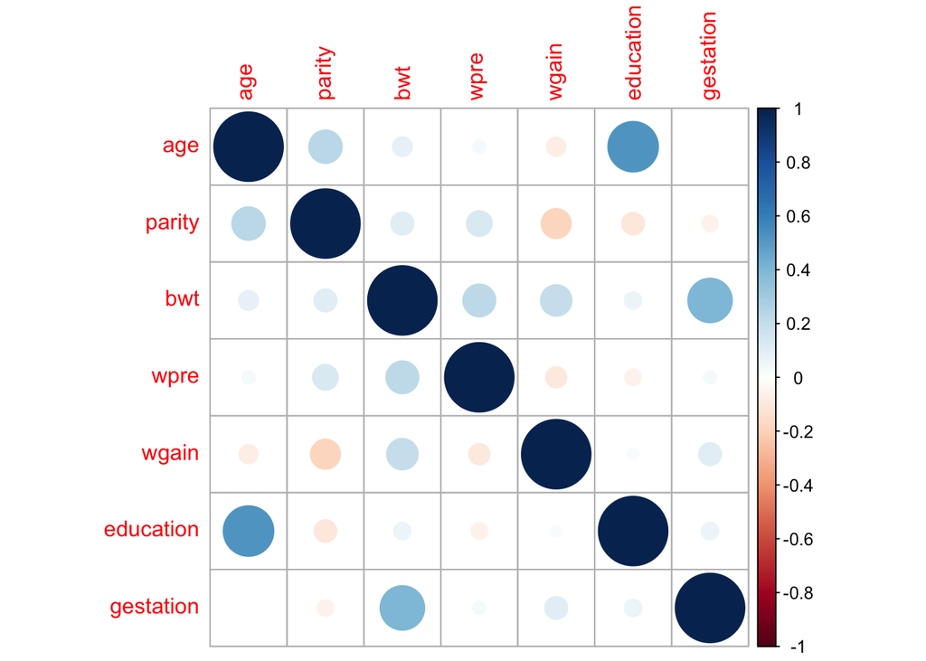

```r
library(corrplot)
corrplot(corr_matrix)
```

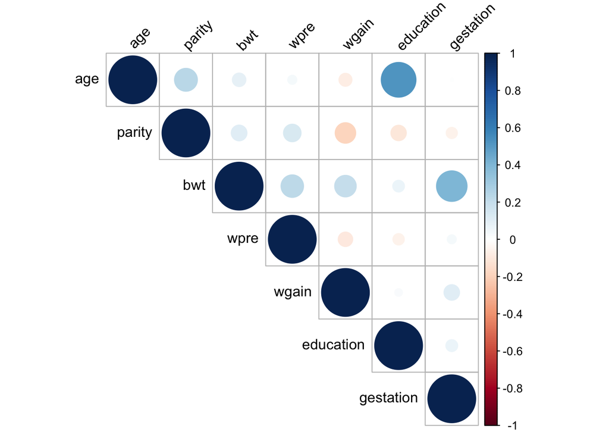

```r
corrplot(corr_matrix, type = "upper", tl.col = "black", tl.srt = 45)
```

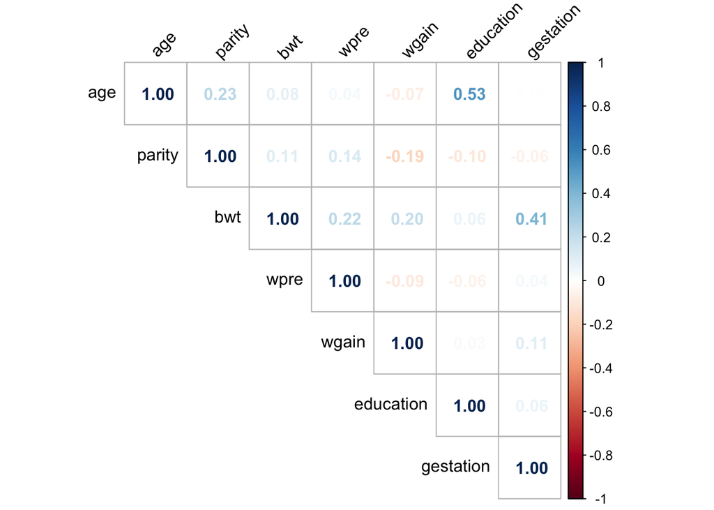

```r
corrplot(corr_matrix, method = "number", type = "upper", tl.col = "black", tl.srt = 45)
```

We can also use the `rcorr` function from the `Hmisc` package to print out a correlation matrix of correlation values by accessing r (`$r`). The correlation value often isn’t enough and a test for each pair of covariates should be performed to see which correlations are significant. This can be done by accessing P (`$P`).

```r
library(Hmisc)

data_matrix <- as.matrix(data_subset)
corr_res <- rcorr(data_matrix, type = "spearman")
print(round(corr_res$r, digits = 2))
```

```
##             age parity  bwt  wpre wgain education gestation
## age        1.00   0.23 0.08  0.04 -0.07      0.53      0.00
## parity     0.23   1.00 0.11  0.14 -0.19     -0.10     -0.06
## bwt        0.08   0.11 1.00  0.22  0.20      0.06      0.41
## wpre       0.04   0.14 0.22  1.00 -0.09     -0.06      0.04
## wgain     -0.07  -0.19 0.20 -0.09  1.00      0.03      0.11
## education  0.53  -0.10 0.06 -0.06  0.03      1.00      0.06
## gestation  0.00  -0.06 0.41  0.04  0.11      0.06      1.00
```

```r
print(round(corr_res$P, digits = 3))
```

```
##             age parity   bwt  wpre wgain education gestation
## age          NA  0.000 0.000 0.065 0.000     0.000     0.835
## parity    0.000     NA 0.000 0.000 0.000     0.000     0.006
## bwt       0.000  0.000    NA 0.000 0.000     0.002     0.000
## wpre      0.065  0.000 0.000    NA 0.000     0.004     0.075
## wgain     0.000  0.000 0.000 0.000    NA     0.187     0.000
## education 0.000  0.000 0.002 0.004 0.187        NA     0.002
## gestation 0.835  0.006 0.000 0.075 0.000     0.002        NA
```

## Model Selection

Model selection is the process of identifying the best set of covariates for a model, and this depends on the type of model you are fitting, e.g., the purpose of the model. Prediction models should be parsimonious and **only** include covariates that help predict the outcome. Causal models should control for known confounders and effect measure modification, and should be based on domain knowledge or previous literature.

### Prediction models

Prediction models are used to make future predictions of the outcome from a set of values from the explanatory variables (predictors). We should only include explanatory variables that help predict or explain the variability in the outcome y; this is called a parsimonious model. Stepwise selection is often used for model selection, where variables are added or removed until the best performing model is found.

#### Stepwise regression

Forward selection starts with an empty model (containing only the intercept), and adds variables one by one, selecting the variable that provides the most significant improvement in model fit at each step. This continues until adding no further variables significantly improves the model.

The output will show iterations, and we can use the `summary` function to display the final model. In this case, the final model included `gestation`, `wpre`, `wgain`, `gender`, `smoker`, `race`, and `age`.

```r
# 1. Forward Selection
# Start with a null model (intercept only)
null_model <- lm(bwt ~ 1, data = data)

# Define the scope of the full model
full_scope <- formula(lm(bwt ~ firstep + gestation + gender +
                           age + welfare + smoker + drinker +
                           wpre + wgain + race, data = data))

forward_model <- step(null_model, direction = "forward", scope = full_scope)
```

```
## Start:  AIC=31634.92
## bwt ~ 1
##
##             Df Sum of Sq       RSS   AIC
## + gestation  1 217486370 564393970 30822
## + wgain      1  29919069 751961271 31539
## + wpre       1  28833403 753046937 31543
## + smoker     1   9806118 772074222 31605
## + gender     1   9591010 772289331 31606
## + race       4  10540761 771339579 31609
## + age        1   6670786 775209554 31615
## + welfare    1   3279255 778601085 31626
## + firstep    1   1480573 780399768 31632
## <none>                   781880340 31635
## + drinker    1    244913 781635427 31636
##
## Step:  AIC=30822.04
## bwt ~ gestation
##
##           Df Sum of Sq       RSS   AIC
## + wpre     1  23917080 540476889 30716
## + wgain    1  14246172 550147798 30760
## + gender   1  12197950 552196019 30769
## + race     4  10189967 554204003 30784
## + age      1   5244759 559149211 30801
## + smoker   1   4183198 560210771 30805
## + welfare  1    826667 563567303 30820
## + firstep  1    596802 563797168 30821
## <none>                 564393970 30822
## + drinker  1     90222 564303747 30824
##
## Step:  AIC=30715.79
## bwt ~ gestation + wpre
##
##           Df Sum of Sq       RSS   AIC
## + wgain    1  20003199 520473691 30624
## + gender   1  12168664 528308225 30661
## + smoker   1   5660896 534815993 30692
## + race     4   6896540 533580349 30692
## + age      1   4669868 535807021 30696
```

[output cut: 44 more lines]

```
##           Df Sum of Sq       RSS   AIC
## + age      1   4096140 491827823 30496
## + firstep  1    567309 495356654 30514
## <none>                 495923963 30515
## + welfare  1    331070 495592893 30515
## + drinker  1     60108 495863855 30516
##
## Step:  AIC=30495.98
## bwt ~ gestation + wpre + wgain + gender + smoker + race + age
##
##           Df Sum of Sq       RSS   AIC
## <none>                 491827823 30496
## + welfare  1    341487 491486336 30496
## + drinker  1    119515 491708308 30497
## + firstep  1     99034 491728789 30498
```

```r
print("Forward Selection Model:")
```

```
## [1] "Forward Selection Model:"
```

```r
print(summary(forward_model))
```

```
##
## Call:
## lm(formula = bwt ~ gestation + wpre + wgain + gender + smoker +
##     race + age, data = data)
##
## Residuals:
##      Min       1Q   Median       3Q      Max
## -2000.26  -276.27    -6.84   274.18  1521.24
##
## Coefficients:
##                Estimate Std. Error t value Pr(>|t|)
## (Intercept)  -2150.8297   157.6381 -13.644  < 2e-16 ***
## gestation      116.9456     3.7855  30.893  < 2e-16 ***
## wpre             3.1031     0.2664  11.650  < 2e-16 ***
## wgain            7.0537     0.6799  10.375  < 2e-16 ***
## genderM        134.3881    17.8121   7.545 6.31e-14 ***
## smokerY       -182.4192    35.6612  -5.115 3.37e-07 ***
## raceblack      -47.2143    40.9445  -1.153 0.248968
## racehispanic   130.9931    38.2908   3.421 0.000634 ***
## raceother       94.9887    83.7363   1.134 0.256745
## racewhite       90.3979    25.5975   3.532 0.000421 ***
## age              7.1036     1.5602   4.553 5.54e-06 ***
## ---
## Signif. codes:  0 '***' 0.001 '**' 0.01 '*' 0.05 '.' 0.1 ' ' 1
##
## Residual standard error: 444.5 on 2489 degrees of freedom
## Multiple R-squared:  0.371,  Adjusted R-squared:  0.3684
## F-statistic: 146.8 on 10 and 2489 DF,  p-value: < 2.2e-16
```

Backward elimination starts with a full model and removes variables one by one, eliminating the variable that contributes the least to the model’s fit each time. This continues until removing no further variables significantly improves the model or all remaining variables are deemed significant.

The output will show iterations, and we can again use the `summary` function to display the final model. In this case, the final model included `gestation`, `wpre`, `wgain`, `gender`, `smoker`, `race`, and `age`.

```r
# 2. Backward Elimination
# Start with a full model
full_model <- lm(bwt ~ firstep + gestation + gender +
                           age + welfare + smoker + drinker +
                           wpre + wgain + race, data = data)

backward_model <- step(full_model, direction = "backward")
```

```
## Start:  AIC=30499.32
## bwt ~ firstep + gestation + gender + age + welfare + smoker +
##     drinker + wpre + wgain + race
##
##             Df Sum of Sq       RSS   AIC
## - firstep    1     67950 491371223 30498
## - drinker    1    114857 491418130 30498
## - welfare    1    306538 491609811 30499
## <none>                   491303272 30499
## - age        1   3733580 495036852 30516
## - race       4   5453513 496756785 30519
## - smoker     1   4579697 495882969 30520
## - gender     1  11180402 502483675 30554
## - wgain      1  21400400 512703672 30604
## - wpre       1  27062854 518366126 30631
## - gestation  1 186745816 678049089 31303
##
## Step:  AIC=30497.66
## bwt ~ gestation + gender + age + welfare + smoker + drinker +
##     wpre + wgain + race
##
##             Df Sum of Sq       RSS   AIC
## - drinker    1    115113 491486336 30496
## - welfare    1    337085 491708308 30497
## <none>                   491371223 30498
## - age        1   4164684 495535907 30517
## - race       4   5466110 496837332 30517
## - smoker     1   4655968 496027191 30519
## - gender     1  11161985 502533208 30552
## - wgain      1  21349637 512720859 30602
## - wpre       1  26994946 518366168 30629
## - gestation  1 186973657 678344880 31302
##
## Step:  AIC=30496.25
## bwt ~ gestation + gender + age + welfare + smoker + wpre + wgain +
##     race
##
##             Df Sum of Sq       RSS   AIC
## - welfare    1    341487 491827823 30496
## <none>                   491486336 30496
## - age        1   4106558 495592893 30515
## - race       4   5423367 496909703 30516
## - smoker     1   4752469 496238804 30518
## - gender     1  11185542 502671877 30550
## - wgain      1  21315770 512802105 30600
## - wpre       1  27064346 518550682 30628
## - gestation  1 187090430 678576765 31301
##
## Step:  AIC=30495.98
## bwt ~ gestation + gender + age + smoker + wpre + wgain + race
##
##             Df Sum of Sq       RSS   AIC
## <none>                   491827823 30496
## - age        1   4096140 495923963 30515
## - race       4   5819576 497647399 30517
## - smoker     1   5170558 496998381 30520
## - gender     1  11248136 503075959 30550
## - wgain      1  21270522 513098345 30600
## - wpre       1  26817425 518645248 30627
## - gestation  1 188587163 680414986 31305
```

```r
print("Backward Elimination Model:")
```

```
## [1] "Backward Elimination Model:"
```

```r
print(summary(backward_model))
```

```
##
## Call:
## lm(formula = bwt ~ gestation + gender + age + smoker + wpre +
##     wgain + race, data = data)
##
## Residuals:
##      Min       1Q   Median       3Q      Max
## -2000.26  -276.27    -6.84   274.18  1521.24
##
## Coefficients:
##                Estimate Std. Error t value Pr(>|t|)
## (Intercept)  -2150.8297   157.6381 -13.644  < 2e-16 ***
## gestation      116.9456     3.7855  30.893  < 2e-16 ***
## genderM        134.3881    17.8121   7.545 6.31e-14 ***
## age              7.1036     1.5602   4.553 5.54e-06 ***
## smokerY       -182.4192    35.6612  -5.115 3.37e-07 ***
## wpre             3.1031     0.2664  11.650  < 2e-16 ***
## wgain            7.0537     0.6799  10.375  < 2e-16 ***
## raceblack      -47.2143    40.9445  -1.153 0.248968
## racehispanic   130.9931    38.2908   3.421 0.000634 ***
## raceother       94.9887    83.7363   1.134 0.256745
## racewhite       90.3979    25.5975   3.532 0.000421 ***
## ---
## Signif. codes:  0 '***' 0.001 '**' 0.01 '*' 0.05 '.' 0.1 ' ' 1
##
## Residual standard error: 444.5 on 2489 degrees of freedom
## Multiple R-squared:  0.371,  Adjusted R-squared:  0.3684
## F-statistic: 146.8 on 10 and 2489 DF,  p-value: < 2.2e-16
```

Hybrid (bidirectional) selection combines both forward and backward movements at each step. At each iteration, it considers adding a new variable (like forward selection) and removing an existing variable (like backward elimination). It selects the action (add or remove) that results in the greatest improvement in model fit. This process continues until no further additions or removals improve the model.

The output will show iterations, and we can again use the `summary` function to display the final model. In this case, the final model included `gestation`, `wpre`, `wgain`, `gender`, `smoker`, `race`, and `age`.

```r
# 3. Hybrid Stepwise Selection
# Can start from a null or full model, or any intermediate model
hybrid_model <- step(null_model, direction = "both", scope = full_scope)
```

```
## Start:  AIC=31634.92
## bwt ~ 1
##
##             Df Sum of Sq       RSS   AIC
## + gestation  1 217486370 564393970 30822
## + wgain      1  29919069 751961271 31539
## + wpre       1  28833403 753046937 31543
## + smoker     1   9806118 772074222 31605
## + gender     1   9591010 772289331 31606
## + race       4  10540761 771339579 31609
## + age        1   6670786 775209554 31615
## + welfare    1   3279255 778601085 31626
## + firstep    1   1480573 780399768 31632
## <none>                   781880340 31635
## + drinker    1    244913 781635427 31636
##
## Step:  AIC=30822.04
## bwt ~ gestation
##
##             Df Sum of Sq       RSS   AIC
## + wpre       1  23917080 540476889 30716
## + wgain      1  14246172 550147798 30760
## + gender     1  12197950 552196019 30769
## + race       4  10189967 554204003 30784
## + age        1   5244759 559149211 30801
## + smoker     1   4183198 560210771 30805
## + welfare    1    826667 563567303 30820
## + firstep    1    596802 563797168 30821
## <none>                   564393970 30822
## + drinker    1     90222 564303747 30824
## - gestation  1 217486370 781880340 31635
##
## Step:  AIC=30715.79
## bwt ~ gestation + wpre
##
##             Df Sum of Sq       RSS   AIC
## + wgain      1  20003199 520473691 30624
## + gender     1  12168664 528308225 30661
## + smoker     1   5660896 534815993 30692
## + race       4   6896540 533580349 30692
```

[output cut: 72 more lines]

```
## Step:  AIC=30495.98
## bwt ~ gestation + wpre + wgain + gender + smoker + race + age
##
##             Df Sum of Sq       RSS   AIC
## <none>                   491827823 30496
## + welfare    1    341487 491486336 30496
## + drinker    1    119515 491708308 30497
## + firstep    1     99034 491728789 30498
## - age        1   4096140 495923963 30515
## - race       4   5819576 497647399 30517
## - smoker     1   5170558 496998381 30520
## - gender     1  11248136 503075959 30550
## - wgain      1  21270522 513098345 30600
## - wpre       1  26817425 518645248 30627
## - gestation  1 188587163 680414986 31305
```

```r
print("Hybrid Stepwise Model:")
```

```
## [1] "Hybrid Stepwise Model:"
```

```r
print(summary(hybrid_model))
```

```
##
## Call:
## lm(formula = bwt ~ gestation + wpre + wgain + gender + smoker +
##     race + age, data = data)
##
## Residuals:
##      Min       1Q   Median       3Q      Max
## -2000.26  -276.27    -6.84   274.18  1521.24
##
## Coefficients:
##                Estimate Std. Error t value Pr(>|t|)
## (Intercept)  -2150.8297   157.6381 -13.644  < 2e-16 ***
## gestation      116.9456     3.7855  30.893  < 2e-16 ***
## wpre             3.1031     0.2664  11.650  < 2e-16 ***
## wgain            7.0537     0.6799  10.375  < 2e-16 ***
## genderM        134.3881    17.8121   7.545 6.31e-14 ***
## smokerY       -182.4192    35.6612  -5.115 3.37e-07 ***
## raceblack      -47.2143    40.9445  -1.153 0.248968
## racehispanic   130.9931    38.2908   3.421 0.000634 ***
## raceother       94.9887    83.7363   1.134 0.256745
## racewhite       90.3979    25.5975   3.532 0.000421 ***
## age              7.1036     1.5602   4.553 5.54e-06 ***
## ---
## Signif. codes:  0 '***' 0.001 '**' 0.01 '*' 0.05 '.' 0.1 ' ' 1
##
## Residual standard error: 444.5 on 2489 degrees of freedom
## Multiple R-squared:  0.371,  Adjusted R-squared:  0.3684
## F-statistic: 146.8 on 10 and 2489 DF,  p-value: < 2.2e-16
```

All three methods resulted in the same final model.

### Causal models

```r
m <- lm(bwt ~ firstep + gestation + age + welfare +
          smoker + drinker + wpre + wgain + race,
        data = data)
summary(m)
```

```
##
## Call:
## lm(formula = bwt ~ firstep + gestation + age + welfare + smoker +
##     drinker + wpre + wgain + race, data = data)
##
## Residuals:
##      Min       1Q   Median       3Q      Max
## -2059.49  -286.96     8.57   275.98  1582.21
##
## Coefficients:
##                Estimate Std. Error t value Pr(>|t|)
## (Intercept)  -2036.6494   159.6849 -12.754  < 2e-16 ***
## firstep        -13.0216    26.2990  -0.495 0.620548
## gestation      115.7529     3.8333  30.197  < 2e-16 ***
## age              6.9592     1.6199   4.296 1.80e-05 ***
## welfare        -97.4142    72.0268  -1.352 0.176347
## smokerY       -174.2710    36.4732  -4.778 1.87e-06 ***
## drinkerY       -69.8747    84.4109  -0.828 0.407867
## wpre             3.1275     0.2701  11.578  < 2e-16 ***
## wgain            7.1616     0.6877  10.413  < 2e-16 ***
## raceblack      -40.4257    41.8529  -0.966 0.334188
## racehispanic   133.9967    39.0928   3.428 0.000619 ***
## raceother      117.0642    84.8951   1.379 0.168041
## racewhite       92.9300    25.9126   3.586 0.000342 ***
## ---
## Signif. codes:  0 '***' 0.001 '**' 0.01 '*' 0.05 '.' 0.1 ' ' 1
##
## Residual standard error: 449.5 on 2487 degrees of freedom
## Multiple R-squared:  0.3573, Adjusted R-squared:  0.3542
## F-statistic: 115.2 on 12 and 2487 DF,  p-value: < 2.2e-16
```